# trial-a fit overview

Pawel Sadlowski

trial-a was fit to data preprocessed with RP method A and limited to 10 most popular items. Price shock was scaled by a factor of 12 to roughly match N(0,3).

v3b1 model was used with k=30

Runtime ranged 6.8-8.9h and max memory use was not measured. RDS fit file measures approx. 900MB.

18 divergencies

# Sampling problems

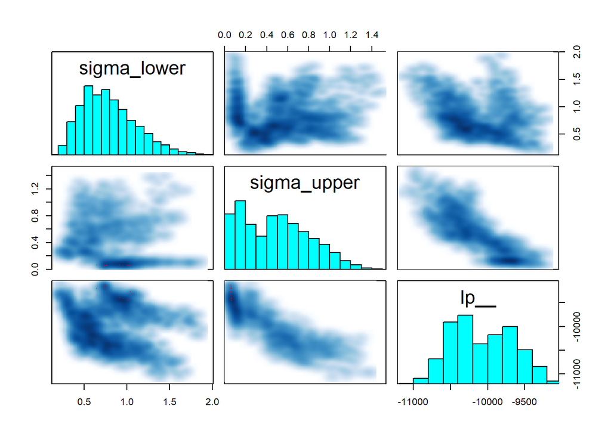

```r
pairs( fit, pars = c( 'sigma_lower', 'sigma_upper', 'lp__'))
```

The graphs look rather nasty and there’s still strong pulling towards homogeneous threshold values

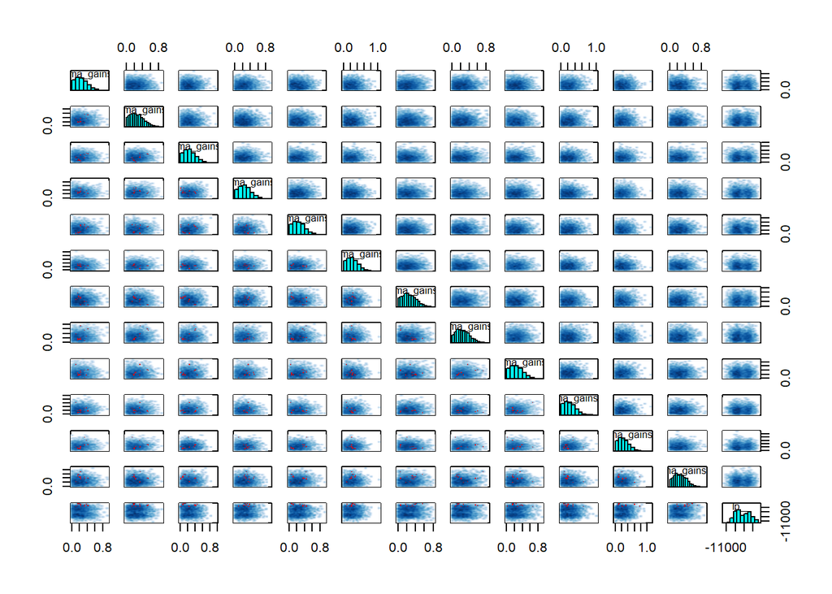

```r
pairs( fit, pars = c( 'sigma_gains', 'lp__'))
```

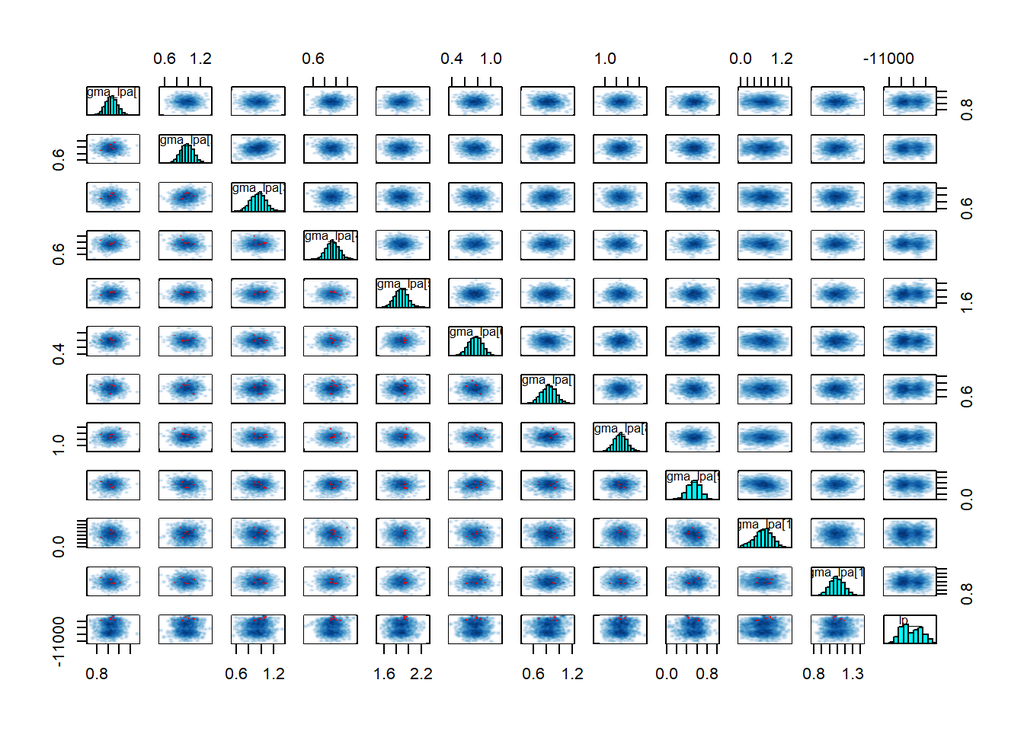

```r
pairs( fit, pars = c( 'sigma_lpa', 'lp__'))
```

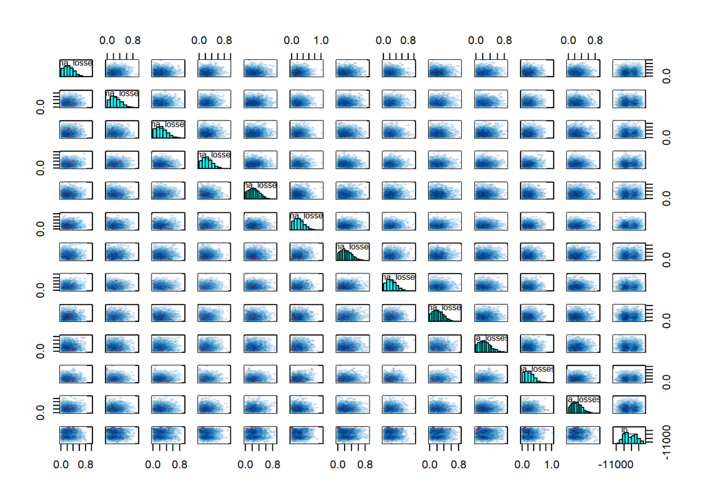

```r
pairs( fit, pars = c( 'sigma_losses', 'lp__'))
```

The problem appears to reside within the threshold parts - no problematic part in beta regression are evident.

# $\hat{R}$

```r
rhat %>%
  is.na() %>% which() %>% names() %>%
  vapply( function( name) {
    a <- unlist( regmatches( ., gregexpr( '\\d+', .)))
    as.numeric( a[1]) > as.numeric( a[2])
  }, FUN.VALUE = TRUE) %>% any()
```

```
## [1] FALSE
```

NA values in $\hat{R}$ only for upper triangle in L matrices (values fixed at 0).

```r
rhat %>%
  `[`( !is.na( .)) %>% max()
```

```
## [1] 2.17495
```

Certain $\hat{R}$ values exceed commonly accepted limits by a wide margin.

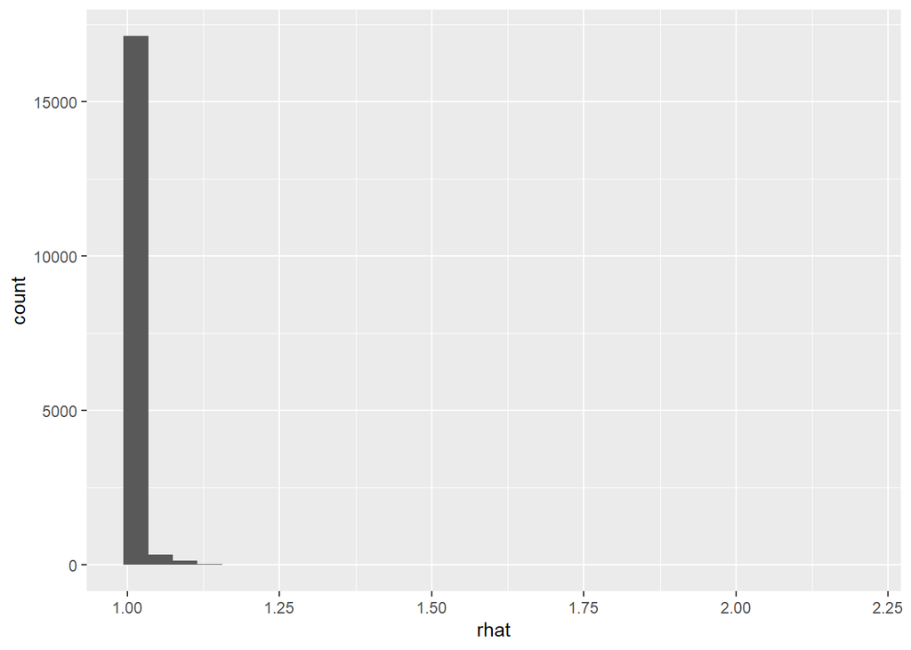

```r
ggplot() +
  geom_histogram( data = data.frame( rhat = rhat[!is.na( rhat)]), aes( x = rhat))
```

Up to 1.1 isn’t uncommon, which is questionable

```r
which( rhat[!is.na( rhat)] > 1.03) %>% names()
```

```
##   [1] "theta_lower[1]" "theta_lower[2]" "theta_lower[3]" "theta_lower[4]"
##   [5] "theta_lower[5]" "theta_upper[1]" "theta_upper[2]" "theta_upper[3]"
##   [9] "theta_upper[4]" "sigma_lower"    "sigma_upper"    "r_lower[1]"
##  [13] "r_lower[2]"     "r_lower[3]"     "r_lower[4]"     "r_lower[5]"
##  [17] "r_lower[6]"     "r_lower[7]"     "r_lower[8]"     "r_lower[9]"
##  [21] "r_lower[10]"    "r_lower[11]"    "r_lower[12]"    "r_lower[13]"
##  [25] "r_lower[15]"    "r_lower[16]"    "r_lower[17]"    "r_lower[18]"
##  [29] "r_lower[19]"    "r_lower[20]"    "r_lower[21]"    "r_lower[22]"
##  [33] "r_lower[23]"    "r_lower[24]"    "r_lower[25]"    "r_lower[26]"
##  [37] "r_lower[28]"    "r_lower[29]"    "r_lower[30]"    "r_lower[31]"
##  [41] "r_lower[32]"    "r_lower[33]"    "r_lower[35]"    "r_lower[36]"
##  [45] "r_lower[37]"    "r_lower[38]"    "r_lower[39]"    "r_lower[40]"
##  [49] "r_lower[41]"    "r_lower[42]"    "r_lower[43]"    "r_lower[44]"
##  [53] "r_lower[45]"    "r_lower[46]"    "r_lower[47]"    "r_lower[48]"
##  [57] "r_lower[50]"    "r_lower[51]"    "r_lower[52]"    "r_lower[53]"
```

[output cut: 122 more lines]

It happens almost exclusively to thresholds (even though it includes the log posterior as well)

```r
rhat[c( 'sigma_lower', 'sigma_upper', 'lp__')]
```

```
## sigma_lower sigma_upper        lp__
##    1.327136    2.174950    2.062002
```

$\hat{R}$ value for both $\sigma_r$ and the log posterior exceed commonly accepted limits.

```r
which( rhat[!is.na( rhat)] > 1.03) %>% names() %>%
  `[`( grep( '(r_)|(beta_)', .)) %>%
  regmatches( ., regexpr( '\\d+', .)) %>%
  as.numeric() %>% unique() -> high_rhat
table( data$h_id)[high_rhat] %>% table()
```

```
## .
##  1  2  3  4  5  6  7  8  9 10 11 12 13 14 15 16 17 18 19 20 21 22 23 25 26 27
## 80 38 49 32 31 26 28 23 11 10 10  4 12  5  2  5  4  5  1  2  3  1  1  2  2  1
## 28 31 33 35 47
##  1  2  1  1  1
```

```r
data$N / data$H
```

```
## [1] 6.412162
```

On average, there are 6-7 observations per customer, which is definitely a low figure considering that there are 12 individual-specific parameters to be estimated. On the other hand, this probably shouldn’t contribute to bad mixing. It could also be caused by low variability in prices, I guess.

```r
all( data$h_id %in% high_rhat)
```

```
## [1] FALSE
```

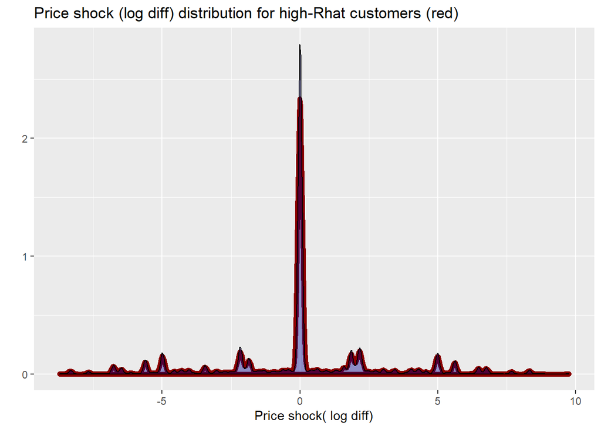

```r
ggplot( data.frame( ps = as.vector( data$ps[,data$h_id %in% high_rhat]))) +
  geom_density( aes( x = ps), color = 'darkred', lwd = 2) +
  geom_density( data = data.frame( x2 = as.vector( data$ps)), aes( x = x2),
                  fill = 'darkblue', alpha = 0.4) +
  ggtitle( 'Price shock (log diff) distribution for high-Rhat customers (red)') +
  xlab( 'Price shock( log diff)') + ylab( '')
```

Somewhat surprising that the match is SO accurate. Might be an artifact in the data.

```r
mean( rhat[!is.na( rhat)] > 1.03)
```

```
## [1] 0.03108514
```

```r
rm( high_rhat)
```

$\hat{R}$ was higher than 1.03 for approx. 3% of parameters, which isn’t a lot, but is a considerable figure.

# Bulk ESS

```r
apply( posterior, 3, ess_bulk) %>% is.na() %>% which() %>% names() %>%
  vapply( function( name) {
    a <- unlist( regmatches( ., gregexpr( '\\d+', .)))
    as.numeric( a[1]) > as.numeric( a[2])
  }, FUN.VALUE = TRUE) %>% any()
```

```
## [1] FALSE
```

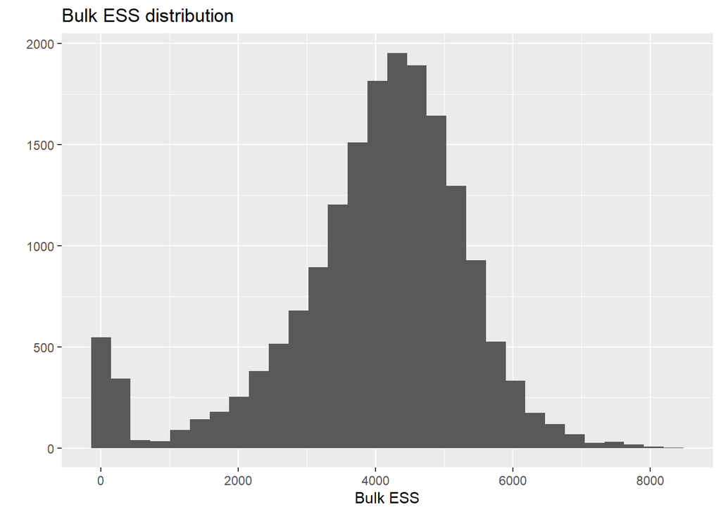

```r
ggplot( data.frame( ess = ess)) +
  geom_histogram( aes( x = ess)) +
  ggtitle( 'Bulk ESS distribution') +
  xlab( 'Bulk ESS') + ylab( '')
```

It is a clearly visible problem in the lower tail of the bulk ESS distribution

```r
sprintf( '%.2f pct parameters with bulk ESS lower than 1k and %.2f pct lower than 100',
         mean( ess < 1e3) * 100, mean( ess < 100) * 100)
```

```
## [1] "5.46 pct parameters with bulk ESS lower than 1k and 2.41 pct lower than 100"
```

# Tail ESS

```r
apply( posterior, 3, ess_tail) %>% is.na() %>% which() %>% names() %>%
  vapply( function( name) {
    a <- unlist( regmatches( ., gregexpr( '\\d+', .)))
    as.numeric( a[1]) > as.numeric( a[2])
  }, FUN.VALUE = TRUE) %>% any()
```

```
## [1] FALSE
```

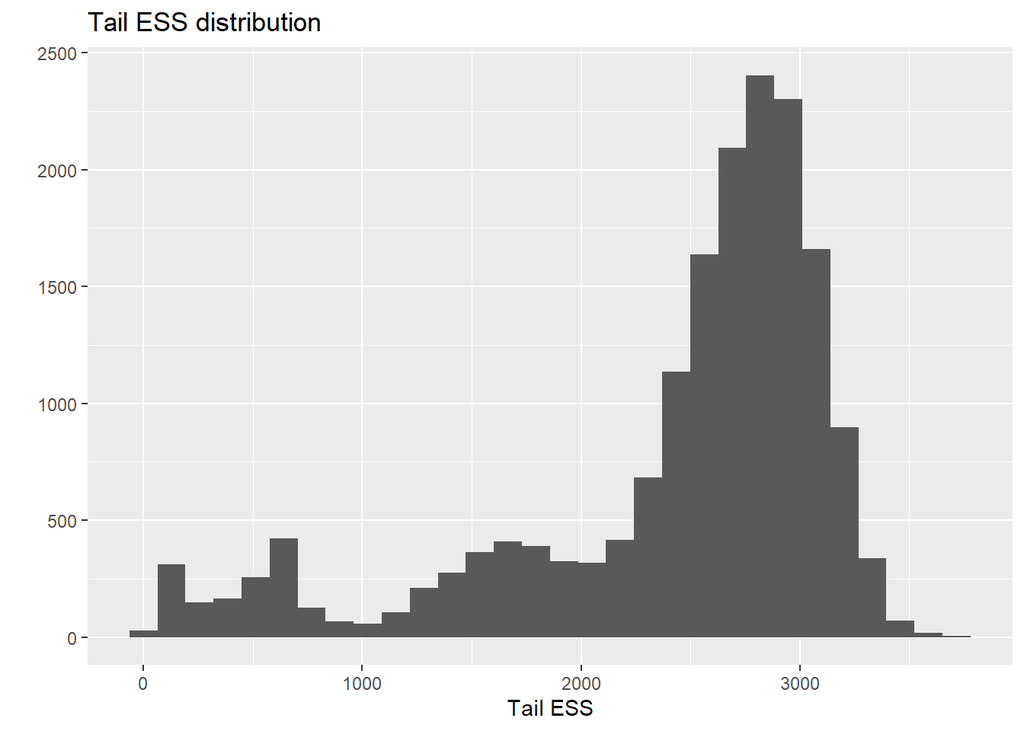

```r
ggplot( data.frame( ess = ess)) +
  geom_histogram( aes( x = ess)) +
  ggtitle( 'Tail ESS distribution') +
  xlab( 'Tail ESS') + ylab( '')
```

Tail ESS behaves better than bulk ESS in this case, but the problematic tail is still visible.

```r
sprintf( '%.2f pct parameters with tail ESS lower than 1k and %.2f pct lower than 100',
         mean( ess < 1e3) * 100, mean( ess < 100) * 100)
```

```
## [1] "8.75 pct parameters with tail ESS lower than 1k and 0.65 pct lower than 100"
```

As above.

# Cross-comparison

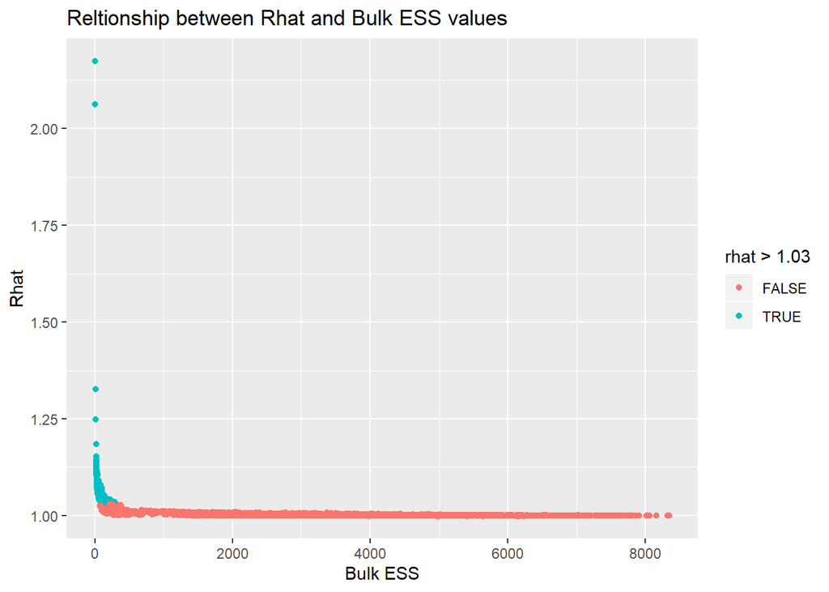

```r
data.frame( pars = names( rhat),
            rhat = rhat,
            ess_bulk = apply( posterior[,,names( rhat)], 3, ess_bulk),
            ess_tail = apply( posterior[,,names( rhat)], 3, ess_tail)) -> plotdata
rm( ess, rhat)
ggplot( plotdata) +
  geom_point( aes( x = ess_bulk, y = rhat, color = rhat > 1.03)) +
  ggtitle( 'Reltionship between Rhat and Bulk ESS values') +
  xlab( 'Bulk ESS') + ylab( 'Rhat')
```

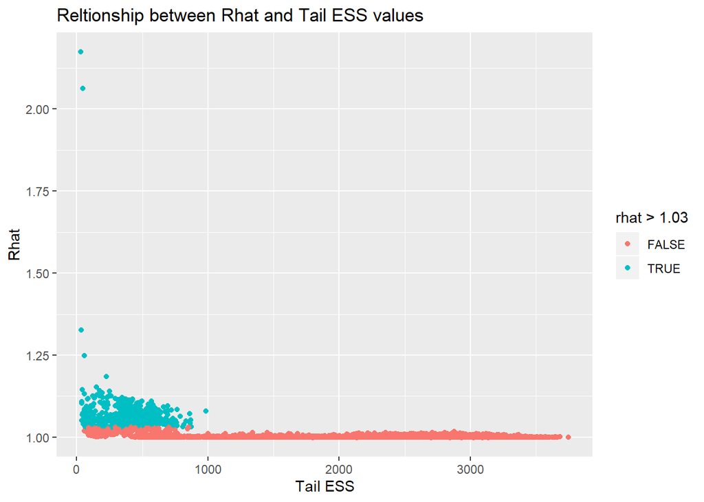

```r
ggplot( plotdata) +
  geom_point( aes( x = ess_tail, y = rhat, color = rhat > 1.03)) +
  ggtitle( 'Reltionship between Rhat and Tail ESS values') +
  xlab( 'Tail ESS') + ylab( 'Rhat')
```

$\hat{R}$ problems usually coincide with low Bulk ESS, the relationship is not as clear for Tail ESS.